# Johns Hopkins Data Science: Practical Machine Learning

## Background Information

> Using devices such as Jawbone Up, Nike FuelBand, and Fitbit it is now possible to collect a large amount of data about personal activity relatively inexpensively. These type of devices are part of the quantified self movement – a group of enthusiasts who take measurements about themselves regularly to improve their health, to find patterns in their behavior, or because they are tech geeks. One thing that people regularly do is quantify how much of a particular activity they do, but they rarely quantify how well they do it. In this project, your goal will be to use data from accelerometers on the belt, forearm, arm, and dumbell of 6 participants. They were asked to perform barbell lifts correctly and incorrectly in 5 different ways. More information is available from the website here: http://web.archive.org/web/20161224072740/http:/groupware.les.inf.puc-rio.br/har (see the section on the Weight Lifting Exercise Dataset).

## Data Wrangling

Data can be found at the following links:

```
    1. *Training* https://d396qusza40orc.cloudfront.net/predmachlearn/pml-training.csv
    2. *Testing* https://d396qusza40orc.cloudfront.net/predmachlearn/pml-testing.csv
```

```r
library(pROC)
```

At this point we have three individual data sets, a training set, a testing set, and a validation set, with 59 variables in the sets.

### Model Building

We can test the most popular supervised classification models: Random Forest, SVM, and K-Nearest Neighbors.

First let’s set up cross validation

```r
tcontrol <- trainControl(method = cv, number = 10, verboseIter = F)
```

[output not shown]

#### Random Forest

[output not shown]

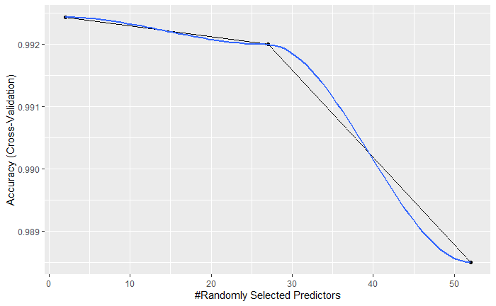

```r
ggplot(data = randFor, mapping = aes(x = results$mtry, y = results$Accuracy)) + geom_smooth()
```

```r
confusionMatrix(rfpredict, factor(testing$classe))
```

```
Confusion Matrix and Statistics

          Reference
Prediction    A    B    C    D    E
         A 1172    4    0    0    0
         B    0  791    5    0    0
         C    0    3  714   15    0
         D    0    0    0  657    0
         E    0    0    0    3  758

Overall Statistics

               Accuracy : 0.9927
                 95% CI : (0.9896, 0.9951)
    No Information Rate : 0.2843
    P-Value [Acc > NIR] : < 2.2e-16

                  Kappa : 0.9908

 Mcnemar's Test P-Value : NA

Statistics by Class:

                     Class: A Class: B Class: C Class: D Class: E
Sensitivity            1.0000   0.9912   0.9930   0.9733   1.0000
Specificity            0.9986   0.9985   0.9947   1.0000   0.9991
Pos Pred Value         0.9966   0.9937   0.9754   1.0000   0.9961
Neg Pred Value         1.0000   0.9979   0.9985   0.9948   1.0000
Prevalence             0.2843   0.1936   0.1744   0.1638   0.1839
Detection Rate         0.2843   0.1919   0.1732   0.1594   0.1839
Detection Prevalence   0.2853   0.1931   0.1776   0.1594   0.1846
Balanced Accuracy      0.9993   0.9949   0.9939   0.9867   0.9996
```

Well that is much better than I expected, but we can continue with our other models

#### SVM

We’ll use SVM with a linear kernel.

```r
confusionMatrix(svm_predict, factor(testing$classe))
```

```
Confusion Matrix and Statistics

          Reference
Prediction    A    B    C    D    E
         A 1077   99   61   52   33
         B   21  587   71   31  104
         C   35   49  546   71   49
         D   36   12   18  493   39
         E    3   51   23   28  533

Overall Statistics

               Accuracy : 0.7851
                 95% CI : (0.7722, 0.7975)
    No Information Rate : 0.2843
    P-Value [Acc > NIR] : < 2.2e-16

                  Kappa : 0.7268

 Mcnemar's Test P-Value : < 2.2e-16

Statistics by Class:

                     Class: A Class: B Class: C Class: D Class: E
Sensitivity            0.9189   0.7356   0.7594   0.7304   0.7032
Specificity            0.9169   0.9317   0.9401   0.9695   0.9688
Pos Pred Value         0.8147   0.7211   0.7280   0.8244   0.8354
Neg Pred Value         0.9661   0.9362   0.9487   0.9484   0.9354
Prevalence             0.2843   0.1936   0.1744   0.1638   0.1839
Detection Rate         0.2613   0.1424   0.1325   0.1196   0.1293
Detection Prevalence   0.3207   0.1975   0.1820   0.1451   0.1548
Balanced Accuracy      0.9179   0.8336   0.8497   0.8500   0.8360
```

Not quite as good as the random forest, but we’re going to test KNN just in case.

#### KNN

```r
knn <- train(classe~., data = training, method = "knn", preProcess = c("center", "scale"), trControl = tcontrol)

knn_predict <- predict(knn, testing)

confusionMatrix(knn_predict, factor(testing$classe))
```

```
Confusion Matrix and Statistics

          Reference
Prediction    A    B    C    D    E
         A 1156   30    4    0    1
         B    8  749   11    0    6
         C    3   14  685   34    3
         D    5    3   19  632    9
         E    0    2    0    9  739

Overall Statistics

               Accuracy : 0.9609
                 95% CI : (0.9546, 0.9666)
    No Information Rate : 0.2843
    P-Value [Acc > NIR] : < 2.2e-16

                  Kappa : 0.9506

 Mcnemar's Test P-Value : 0.0004877

Statistics by Class:

                     Class: A Class: B Class: C Class: D Class: E
Sensitivity            0.9863   0.9386   0.9527   0.9363   0.9749
Specificity            0.9881   0.9925   0.9841   0.9896   0.9967
Pos Pred Value         0.9706   0.9677   0.9269   0.9461   0.9853
Neg Pred Value         0.9945   0.9854   0.9899   0.9876   0.9944
Prevalence             0.2843   0.1936   0.1744   0.1638   0.1839
Detection Rate         0.2804   0.1817   0.1662   0.1533   0.1793
Detection Prevalence   0.2889   0.1878   0.1793   0.1621   0.1820
Balanced Accuracy      0.9872   0.9655   0.9684   0.9629   0.9858
```

This is also a very good model, and argueably may be better for out of sample error.

#### Validation

We’ll use our best model, testing using the validation set, and a final prediction on our testing set.

```r
val_predicts <- predict(randFor, validation, type = "raw")

confusionMatrix(val_predicts, factor(validation$classe))
```

```
Confusion Matrix and Statistics

          Reference
Prediction   A   B   C   D   E
         A 502   1   0   0   0
         B   0 337   0   0   0
         C   0   3 307   5   0
         D   0   0   0 284   1
         E   0   0   0   0 323

Overall Statistics

               Accuracy : 0.9943
                 95% CI : (0.9896, 0.9973)
    No Information Rate : 0.2847
    P-Value [Acc > NIR] : < 2.2e-16

                  Kappa : 0.9928

 Mcnemar's Test P-Value : NA

Statistics by Class:

                     Class: A Class: B Class: C Class: D Class: E
Sensitivity            1.0000   0.9883   1.0000   0.9827   0.9969
Specificity            0.9992   1.0000   0.9945   0.9993   1.0000
Pos Pred Value         0.9980   1.0000   0.9746   0.9965   1.0000
Neg Pred Value         1.0000   0.9972   1.0000   0.9966   0.9993
Prevalence             0.2847   0.1934   0.1741   0.1639   0.1838
Detection Rate         0.2847   0.1912   0.1741   0.1611   0.1832
Detection Prevalence   0.2853   0.1912   0.1787   0.1617   0.1832
Balanced Accuracy      0.9996   0.9941   0.9973   0.9910   0.9985
```

#### Test Set Predictions

```r
test_set <- read_csv("pml-testing.csv", show_col_types = FALSE)
```

```
* `` -> ...1
```

```r
final_predictions <- predict(randFor, newdata = test_set)
```

### Citations

Ugulino, W.; Cardador, D.; Vega, K.; Velloso, E.; Milidiu, R.; Fuks, H. Wearable Computing: Accelerometers’ Data Classification of Body Postures and Movements. Proceedings of 21st Brazilian Symposium on Artificial Intelligence. Advances in Artificial Intelligence - SBIA 2012. In: Lecture Notes in Computer Science. , pp. 52-61. Curitiba, PR: Springer Berlin / Heidelberg, 2012. ISBN 978-3-642-34458-9. DOI: 10.1007/978-3-642-34459-6_6

Read more: http:/groupware.les.inf.puc-rio.br/har#sbia_paper_section#ixzz4TjprmnaJ